# General linear models

PCB 6455 / BSC 4933: Biometry | Lecture 23

Dr. Brian Maitner

## Today’s agenda

1. Why use a built-in shortcut when `mle2()` already works
2. What makes a model a **general linear model**
3. One question, three classic analyses, one function:
   - **regression** (a continuous predictor)
   - **ANOVA** (a categorical predictor)
   - **ANCOVA** (both)
4. Checking the assumptions and intervals the quick way
5. Drawing the predictions, and checking them against the data
6. Your turn

Type and run on a code block: type it into your script and run it. Code without the label is there to watch.

## The story so far

- We build a model from parts: a **function** for the mean, a **distribution** for the scatter, then fit it by maximum likelihood with `mle2()`
- That works for **any** model we can write down
- **Today:** the most common special case has a fast, built-in shortcut, `lm()`

# Why a shortcut?

## Why use `lm()` at all?

`mle2()` can fit everything `lm()` can. Bolker’s reasons to use `lm()` anyway:

| Reason | What it means |
| --- | --- |
| **fast and stable** | no starting values; it cannot get stuck the way `optim()` can |
| **convention** | “we used linear regression” needs no explaining in a paper |
| **easy to compare** | change the model by adding or removing one term: `y ~ x`, `y ~ z`, `y ~ x + z` |

The cost: it only fits **one shape** of model.

When your model is the standard one, use the standard tool. When it is not, you already know how to build your own.

## What makes a model a “general linear model”

1. **Normal** scatter around the mean
2. The **same** amount of scatter everywhere (constant variance)
3. Each observation **independent** of the others
4. The mean is **linear in the parameters**

We have made the first three before, in any `mle2()` model with a normal distribution and a single fitted `sd` shared by every observation. The fourth is new.

## Linear in what?

“Linear” is about the **parameters**, not the shape of the line:

| Model for the mean | General linear model? |
| --- | --- |
| $a + b\,x$ | yes |
| $a + b\,x^2$ | yes: $x^2$ is just another column of data |
| $a + b\,\log(x)$ | yes, the same reason |
| $a\,x^b$ | **no**: the parameter $b$ is an exponent |

A general linear model multiplies each predictor by a parameter and adds them up; the predictors themselves can be curved.

## In practice: can `lm()` write it?

If you can write the model as an `lm()` formula, it is a general linear model, and `lm()` will fit it.

| Model for the mean | `lm()` formula |
| --- | --- |
| $a + b\,x^2$ | `y ~ I(x^2)` |
| $a + b\,\log(x)$ | `y ~ log(x)` |
| $a + b\,x + c\,z + d\,x z$ | `y ~ x * z` |
| $a\,x^b$ | none |

**Stuck writing the formula?** Look for a parameter that is not simply multiplying a term: in an exponent, inside `exp()`, or in a denominator. Then the model is not linear, and `mle2()` is the tool.

# The question and the data

## Wings and migration

- The **hand-wing index** (HWI) measures how long and pointed a wing is: 100 × (how far the longest flight feather reaches past the others) / (wing length)
- Long, pointed wings make long flights **cheaper**; short, rounded wings are better for quick takeoffs and **maneuvering** through cover
- **AVONET** has the HWI of every bird species, measured on museum specimens and live birds

**The question:** do migratory songbirds have more pointed wings? And does latitude matter, once migration is accounted for?

**The prediction:** higher HWI in migrants, and higher at high latitudes, where seasons are harsher.

## Two songbirds

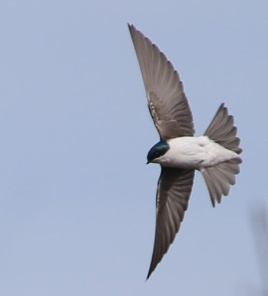

**Tree Swallow**: HWI 53.0, migratory. Long, narrow wings that taper to a point.

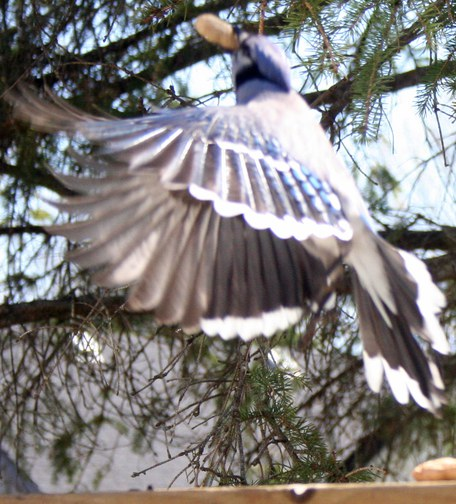

**Blue Jay**: HWI 17.4, mostly resident. Short, broad wings with rounded tips.

Photos: Derald Grimwood, CC0 (left); Robert Taylor, [CC BY 2.0](https://creativecommons.org/licenses/by/2.0/) (right). Both cropped.

## Get set up

```r
library(bbmle)
library(biometrydata)

songbirds <- avonet[avonet$Order1 == "Passeriformes", ]
birds <- data.frame(species = songbirds$Species1,
                    family = songbirds$Family1,
                    hwi = songbirds$Hand.Wing.Index,
                    lat = abs(songbirds$Centroid.Latitude),   # degrees from the equator
                    migration_code = songbirds$Migration,     # 1, 2 or 3
                    habitat_code = songbirds$Habitat.Density) # 1, 2 or 3
birds <- na.omit(birds)
```

**Check:** 6,583 species, down from 6,614.

## What the data look like

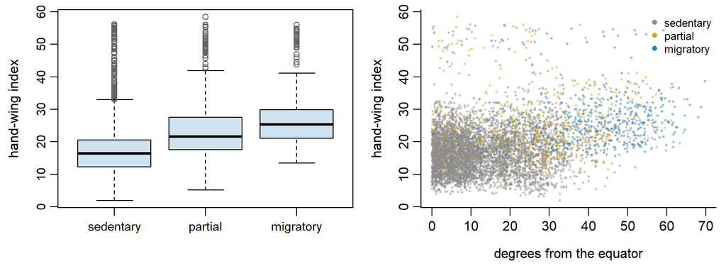

Migrants: HWI 26.6 against 16.9. But they also live farther from the equator: 40° against 13°.

# Regression: a continuous predictor

## The same model, two ways

```r
# names: m_ for mle2() fits, lm_ for lm() fits

# the way we know: write the mean and the distribution
m_lat <- mle2(hwi ~ dnorm(mean = a + b * lat, sd = s),
              start = list(a = 15, b = 0, s = 5), data = birds)

# the shortcut
lm_lat <- lm(hwi ~ lat, data = birds)

coef(m_lat)
coef(lm_lat)
c(logLik(m_lat), logLik(lm_lat))
```

**Check:** both give intercept 15.59, slope 0.171, and log-likelihood -22,448.

lm() is maximum likelihood with a normal distribution; it just gets there by a faster route.

## What `lm()` does for you

|  | `mle2()` | `lm()` |
| --- | --- | --- |
| intercept | you write `a` | included automatically (`- 1` removes it) |
| slope | you write `b * lat` | `lat` means “a slope for `lat`” |
| scatter | you write `dnorm(..., sd = s)` | always normal, `sd` fitted for you |
| starting values | you choose them | none needed |

The formula `hwi ~ lat` is a **shorthand** for $\text{hwi} \sim \text{Normal}(a + b\,\text{lat},\ \sigma)$.

## Reading the fit

```r
summary(lm_lat)       # estimates, standard errors, R-squared
confint(lm_lat)       # 95% confidence intervals
sigma(lm_lat)         # the fitted sd of the scatter: s in the mle2 version
```

**Check:** HWI rises by 0.158 to 0.184 per degree of latitude. $R^2$ is 0.09: latitude explains 9% of the variation.

# ANOVA: a categorical predictor

## The number trap

```r
lm_num <- lm(hwi ~ migration_code, data = birds)   # codes 1, 2, 3 as numbers
coef(lm_num)

# tell R the codes are categories
birds$migration <- factor(birds$migration_code, levels = 1:3,
                          labels = c("sedentary", "partial", "migratory"))
lm_mig <- lm(hwi ~ migration, data = birds)
coef(lm_mig)
AIC(lm_num, lm_mig)
```

**Check:** `lm_num` has one slope, 5.19 per code. `lm_mig` is better by 30.6 AIC units.

## What the coefficients mean

| `coef(lm_mig)` | value | means |
| --- | --- | --- |
| `(Intercept)` | 16.9 | mean HWI of **sedentary** birds, the first level |
| `migrationpartial` | 6.7 | partial migrants **minus** sedentary |
| `migrationmigratory` | 9.6 | migrants **minus** sedentary |

`lm(hwi ~ migration - 1)` gives the three **means** instead: 16.9, 23.7, 26.6. Same model, same fit.

By default R reports the first group, then how far each other group is from it; minus 1 reports each group’s own mean.

# ANCOVA: both

## Latitude and migration together

```r
lm_add <- lm(hwi ~ lat + migration, data = birds)   # one slope, three intercepts
lm_int <- lm(hwi ~ lat * migration, data = birds)   # each group its own slope

AICtab(lm_lat, lm_mig, lm_add, lm_int)
coef(lm_add)
```

**Check:** `lm_add` is best; separate slopes (`lm_int`) are 3.2 units worse.

## Parallel lines

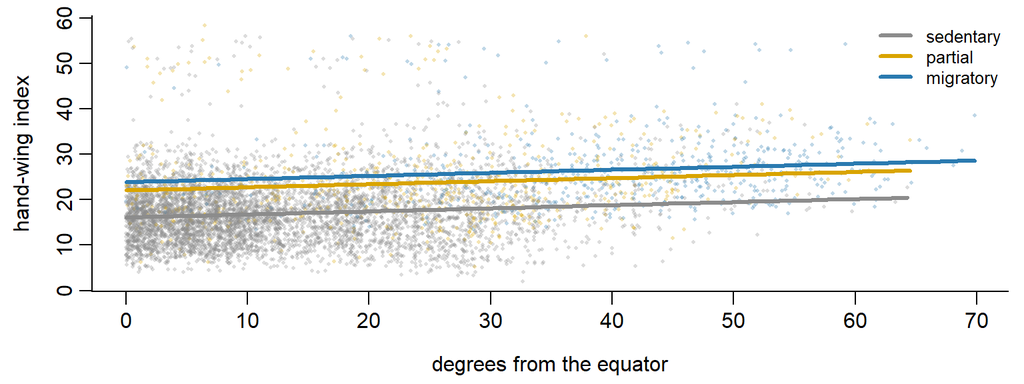

| Formula | Shape |
| --- | --- |
| `hwi ~ lat + migration` | **parallel** lines: one slope, a height per group |
| `hwi ~ lat * migration` | a separate slope for each group |

## Why did the latitude slope shrink?

| Model | HWI per degree of latitude |
| --- | --- |
| `hwi ~ lat` | 0.171 |
| `hwi ~ lat + migration` | 0.068 (0.053 to 0.083) |

Migrants live far from the equator. Alone, latitude got the credit for **migration too**.

When two predictors go together, a model with only one of them gives it credit for both.

# Checking and using the fit

## Are the assumptions met?

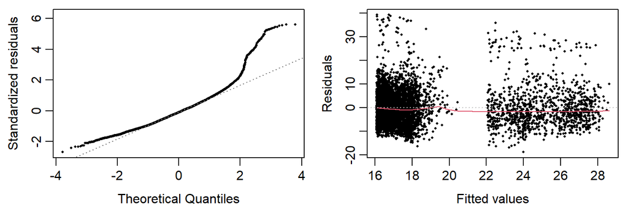

```r
plot(lm_add, which = 2)   # normal Q-Q: are the residuals normal?
plot(lm_add, which = 1)   # residuals against fitted: is the scatter even?
```

**Check:** the points bend up at the right of the Q-Q plot: a long upper tail.

## Intervals, the quick way

```r
# a migratory songbird, 45 degrees from the equator
new_bird <- data.frame(lat = 45,
                       migration = factor("migratory", levels = levels(birds$migration)))

predict(lm_add, newdata = new_bird, interval = "confidence")   # the average bird
predict(lm_add, newdata = new_bird, interval = "prediction")   # one new species
```

**Check:** confidence 26.3 to 27.5; prediction 13.2 to 40.7.

Lecture 21’s recipe gives the same: 26.3 to 27.5, and 13.0 to 40.9.

## Drawing the predictions

```r
library(ggplot2)

# the birds to predict for: every latitude from 0 to 70, in each migration group
grid <- expand.grid(lat = 0:70, migration = levels(birds$migration))
conf <- predict(lm_add, newdata = grid, interval = "confidence")
pred <- predict(lm_add, newdata = grid, interval = "prediction")
grid <- data.frame(grid, conf, pred_lwr = pred[, "lwr"], pred_upr = pred[, "upr"])

ggplot(grid, aes(x = lat)) +
  geom_point(data = birds, aes(y = hwi), size = 0.3, alpha = 0.2) +
  geom_ribbon(aes(ymin = pred_lwr, ymax = pred_upr), fill = "#2a7ab0", alpha = 0.2) +
  geom_ribbon(aes(ymin = lwr, ymax = upr), fill = "#2a7ab0", alpha = 0.6) +
  geom_line(aes(y = fit)) +
  facet_wrap(~ migration) +
  labs(x = "degrees from the equator", y = "hand-wing index")
```

**Check:** `grid` has 213 rows (71 latitudes × 3 groups) and the columns `fit`, `lwr`, `upr`, `pred_lwr`, `pred_upr`.

## Does the model match the data?

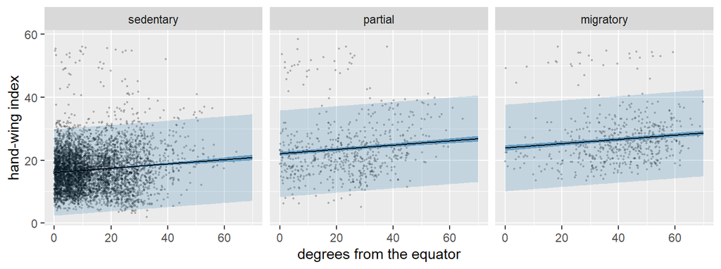

**Think:** does the line run through the middle of the points? About 95% of species should fall in the pale band. Are the misses split evenly above and below?

**Check:** 96% fall inside. But 91% of the misses are **above** the band: the long upper tail from the Q-Q plot.

Look at where the model misses, not only how often.

## Good enough?

The fix for a long upper tail: model `log(hwi)`. Does the answer change?

```r
lm_log <- lm(log(hwi) ~ lat + migration, data = birds)
exp(confint(lm_log))   # back on the HWI scale: each effect is now "times"
exp(predict(lm_log, newdata = new_bird, interval = "prediction"))
```

|  | `hwi ~ ...` | `log(hwi) ~ ...` |
| --- | --- | --- |
| migrants vs sedentary | 7.1 to 8.6 points more | 1.43 to 1.56 times |
| latitude | slope above zero | slope above zero |
| one new migrant at 45° | 13.2 to 40.7 | 12.2 to 55.3 |

The effects hold up; the prediction for one new species does not.

“Good enough” depends on the question: refit with the fix and see whether your answer changes.

# Your turn

## Your turn: habitat

Pointed wings may also suit **open** country, where birds fly farther and need less maneuvering than in forest. `habitat_code`: 1 dense, 2 semi-open, 3 open.

```r
lm_hab_num <- lm(hwi ~ lat + migration + habitat_code, data = birds)

# make habitat a factor here, with labels dense, semi-open and open
# (hint: the number trap slide)

# lm_hab_fac goes here: lm_add plus habitat as a factor

# compare lm_add, lm_hab_num and lm_hab_fac here
```

**Before you fit:** predict which wins.

**Check:** `lm_hab_fac` is best, by 80.4 over `lm_hab_num`; open-country songbirds have wings 4.0 to 5.0 points more pointed than forest birds.

# Wrapping up

## Which formula, when

| You want | Formula | Classic name |
| --- | --- | --- |
| a slope | `y ~ x` | regression |
| a mean for each group | `y ~ f`, or `y ~ f - 1` | one-way ANOVA |
| two sets of groups | `y ~ f1 + f2`, or `y ~ f1 * f2` | two-way ANOVA |
| parallel lines | `y ~ x + f` | ANCOVA |
| a slope for each group | `y ~ x * f` | ANCOVA, with interaction |
| a curve, still linear | `y ~ x + I(x^2)` | polynomial regression |
| not normal, or not linear | `mle2()`, or Thursday’s `glm()` |  |

Group codes stored as numbers: `factor()` first.

## Before next class

Read Bolker **9.3 to 9.4**

Thursday: **generalized linear models** (`glm()`), and **Assignment 4**